# Rapport sur les bases de données du MALARIA

Aliou Diallo

02/11/2021

Enjeux du Sujet: L’Organisation Mondiale de la Santé (OMS) considère que près de la moitié de la population mondiale est menacée par le paludisme, avec environ 216 millions de nouveaux cas et 445 000 décès en 2016, principalement en Afrique subsaharienne. Mais après des décennies de négligence, les efforts de lutte contre la maladie sont entrés dans une ère sans précédent. Pour élérgir notre étude et se poser plus de question sur le paludisme on choisit deux jeu de données, donc l’étude se fera en deux parties à savoir .

```
 I-  Décès dus au paludisme selon l’âge à travers le monde et le temps.(1990-2016
  II-Incidence du paludisme par pays pour tous les âges à travers le monde à travers le      temps(2000-2016)
```

1ére parties:Décès dus au paludisme selon l’âge à travers le monde et le temps.

```
   I-Importation de données
```

```r
malaria_deaths_age <-read_csv("https://raw.githubusercontent.com/rfordatascience/tidytuesday/master/data/2018/2018-11-13/malaria_deaths_age.csv")
```

```
## * `` -> ...1
```

```r
view(malaria_deaths_age)
```

```
Manupulation des données MALARIA DEATHS :
```

Le tableau de données a 6 colonnes. On va les renommer afin de mieux se familiariser avec la base de données. Etant donné que les colonnes “…1” et “code” n’ont pas d’importance, il est préférable de les supprimer.

```r
malaria_deaths_age %>%
  rename(pays = entity, annee = year, tranche_age = age_group, nbr.deces=deaths)%>%
  select( -...1, -code)-> data
data
```

```
## # A tibble: 30,780 x 4
##    pays        annee tranche_age nbr.deces
##    <chr>       <dbl> <chr>           <dbl>
##  1 Afghanistan  1990 Under 5          185.
##  2 Afghanistan  1991 Under 5          192.
##  3 Afghanistan  1992 Under 5          197.
##  4 Afghanistan  1993 Under 5          207.
##  5 Afghanistan  1994 Under 5          226.
##  6 Afghanistan  1995 Under 5          236.
##  7 Afghanistan  1996 Under 5          251.
##  8 Afghanistan  1997 Under 5          258.
##  9 Afghanistan  1998 Under 5          273.
## 10 Afghanistan  1999 Under 5          272.
## # ... with 30,770 more rows
```

```
 1.Nombre de deces dus au paludisme en 1990 en Haiti par tranche d’age?
```

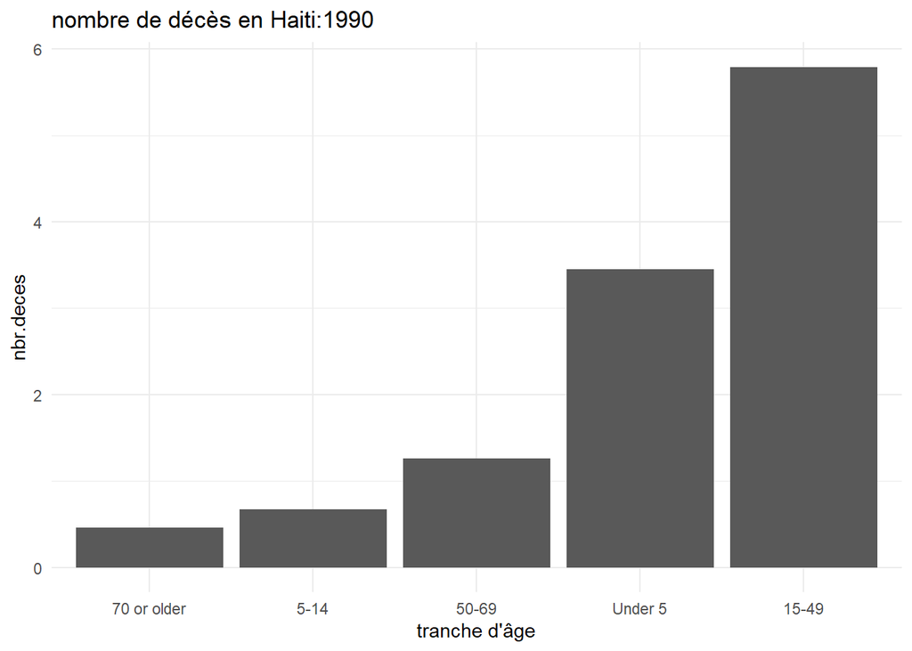

```r
data %>%
  filter(annee == 1990 & pays == "Haiti") %>%
  ggplot(aes(x=reorder(tranche_age,nbr.deces), y = nbr.deces), fill)+
  geom_col()+
  labs(title = "nombre de décès en Haiti:1990")+
  xlab("tranche d'âge")+
  theme_minimal()
```

la jeunesse est plus impacté par la maladie c’est à dire la part de la population dont l’age est compris entre 15 et 49.

```
        2.Quelle est l’evolution du nombre de décès dus au paludisme au Sénégal de 1990 à 2016?
```

Etapes: - Trier le jeu de données: décès dus au paludisme au Sénégal(filter) - Faire un group_by année - Faire un sumarise pour le nombre de décès par an - Faire une représentation graphique du nombre de décé en fonction de l’année

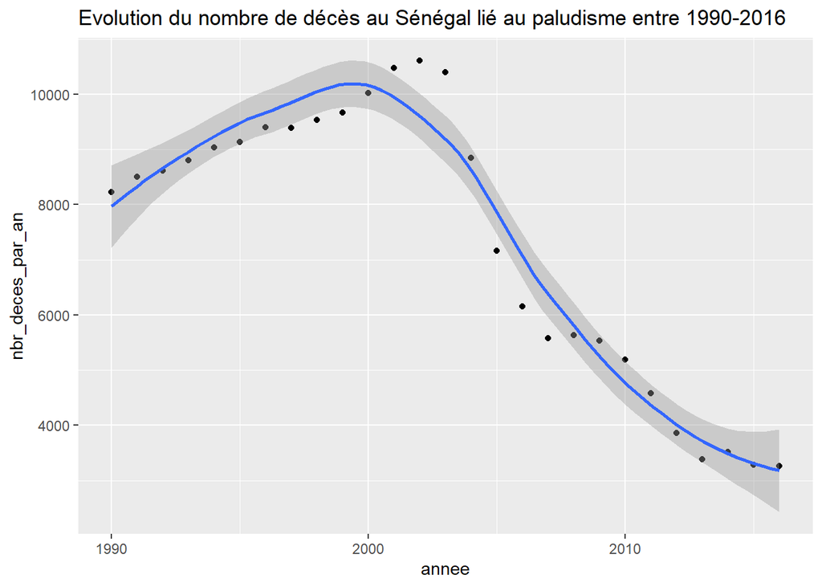

```r
data %>%
  filter(pays =="Senegal")%>%
  group_by(annee)%>%
  summarise(nbr_deces_par_an = sum(nbr.deces)) %>%
  ggplot(aes(x = annee, y = nbr_deces_par_an))+
  geom_point()+
  geom_smooth()+

  labs(title = "Evolution du nombre de décès au Sénégal lié au paludisme entre 1990-2016")
```

Le taux de décés lié aux malaria est croissant entre 1990 et 2000 et diminue progressivement dans la années suivantes.

```
 3.Quelle est l’evolution du nombre de décès dus au paludisme en Bolivia de 1990 à 2016?
```

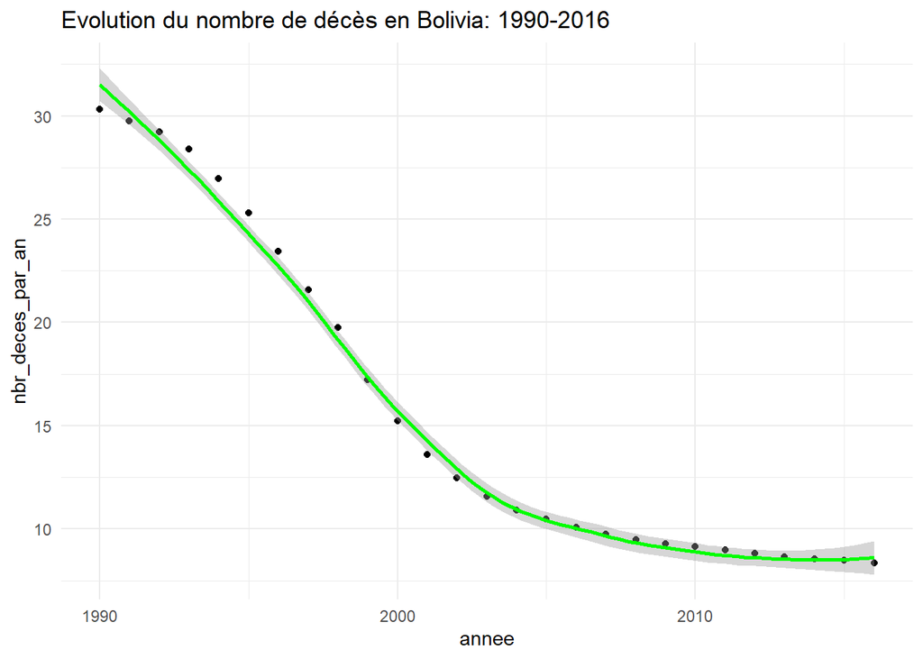

```r
data %>%
  filter(pays == "Bolivia") %>%
  group_by(annee) %>%
  summarise(nbr_deces_par_an = sum(nbr.deces)) %>%
  ggplot(aes(x = annee, y = nbr_deces_par_an))+
  geom_point()+
  geom_smooth(color="green")+
  theme_minimal()+
  labs(title = "Evolution du nombre de décès en Bolivia: 1990-2016")
```

On constate une baisse progréssive du nombre de décés du au paludisme en Bolévia.

```
        4.Quelle est l’evolution du nombre de décès dus au paludisme au canada de 1990 à 2016?
```

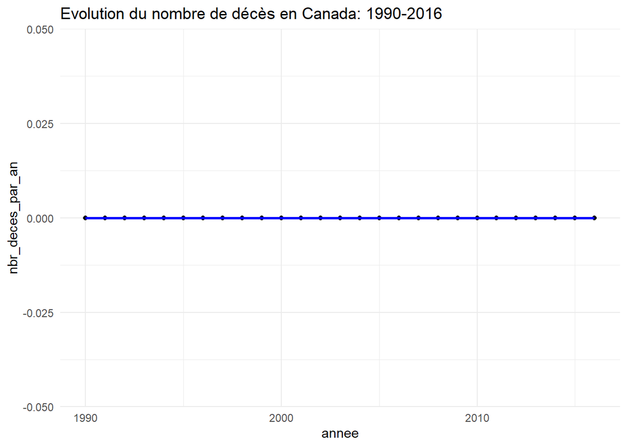

```r
data %>%
  filter(pays == "Canada") %>%
  group_by(annee) %>%
  summarise(nbr_deces_par_an = sum(nbr.deces)) %>%
  ggplot(aes(x = annee, y = nbr_deces_par_an))+
  geom_point()+
  geom_smooth(color="blue")+
  theme_minimal()+
  labs(title = "Evolution du nombre de décès en Canada: 1990-2016")
```

Certain pays ont enrigitrer 0 décé du au paludisme.

```
  5.Quels sont les pays dont la somme des nombres de décès dans le temps est egale à zero?
```

```r
data %>%
   group_by(pays,annee) %>%
  summarise(nbr_deces_par_an = sum(nbr.deces)) %>%
   count(nbr_deces_par_an)%>%
  filter(nbr_deces_par_an == 0) %>%
  select(pays)
```

```
## # A tibble: 102 x 1
## # Groups:   pays [102]
##    pays
##    <chr>
##  1 Albania
##  2 Andorra
##  3 Antigua and Barbuda
##  4 Armenia
##  5 Australasia
##  6 Australia
##  7 Austria
##  8 Bahamas
##  9 Bahrain
## 10 Barbados
## # ... with 92 more rows
```

On peut voir que la plus part de ces pays ne sont pas des pays d’afrique,donc on peut en conclure que ce contienent est plus impacté par cette maladie.

```
     6.Nombre de décès par pays dus au paludisme en 2008?
```

```r
data %>%
  filter(annee == 2008) %>%
  group_by(pays,annee) %>%
  summarise(nbr_deces_par_an = sum(nbr.deces)) ->country_1 #on stock les pays qui enrigistré de #décés dans country_1
```

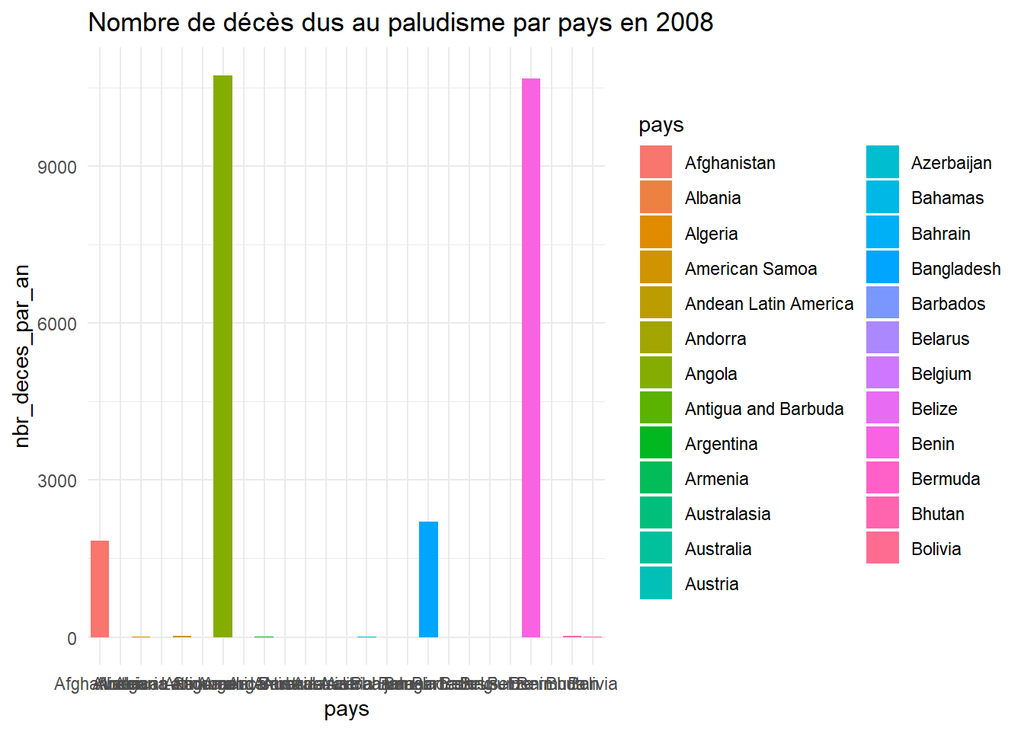

```r
country_1 [1:25,] %>%
  ggplot(aes(x = pays, y = nbr_deces_par_an))+
  geom_col(aes(fill = pays))+
  theme_minimal()+
  labs(title = "Nombre de décès dus au paludisme par pays en 2008")
```

2eme parties: Incidence du paludisme par pays pour tous les âges à travers le monde à travers le temps

Importation de données:

```r
malaria_inc <-read.csv("https://raw.githubusercontent.com/rfordatascience/tidytuesday/master/data/2018/2018-11-13/malaria_inc.csv")
view(malaria_inc)
```

Comme pour le premier jeu de données on change le nom des variables pour mieux se fammiliariser avec les donnée.Puis on stock ce changement comme le “malaria_procéssus_inc”

```r
malaria_processus_inc <- malaria_inc %>%
  setNames(c("pays","code","annee","incidence"))%>%
  mutate(incidence=incidence/1000)
view(malaria_processus_inc)
```

```
    7-Evolution du nombre d'incident du aux paludisme aux Kenya
```

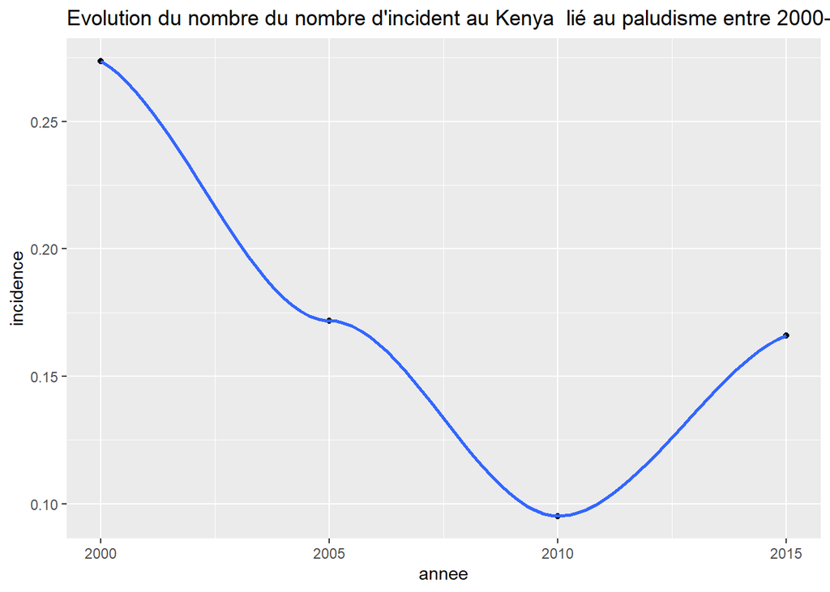

```r
malaria_processus_inc %>%
  filter(pays =="Kenya")%>%
  group_by(annee)%>%
  summarise(incidence = sum(incidence)) %>%
  ggplot(aes(x = annee, y =incidence))+
  geom_point()+
  geom_smooth()+

  labs(title = "Evolution du nombre du nombre d'incident au Kenya  lié au paludisme entre 2000-2015")
```

Au Kenya ,entre 2000 et 2010 ,le nombre d’incident dus au paludisme diminue progrssivement mais ce dernier repart en hausse ces derniers années.

```
  8 Donnons aléatoirement l'évolution  du nombre d'incident dus au paludisme sur 6 pays
```

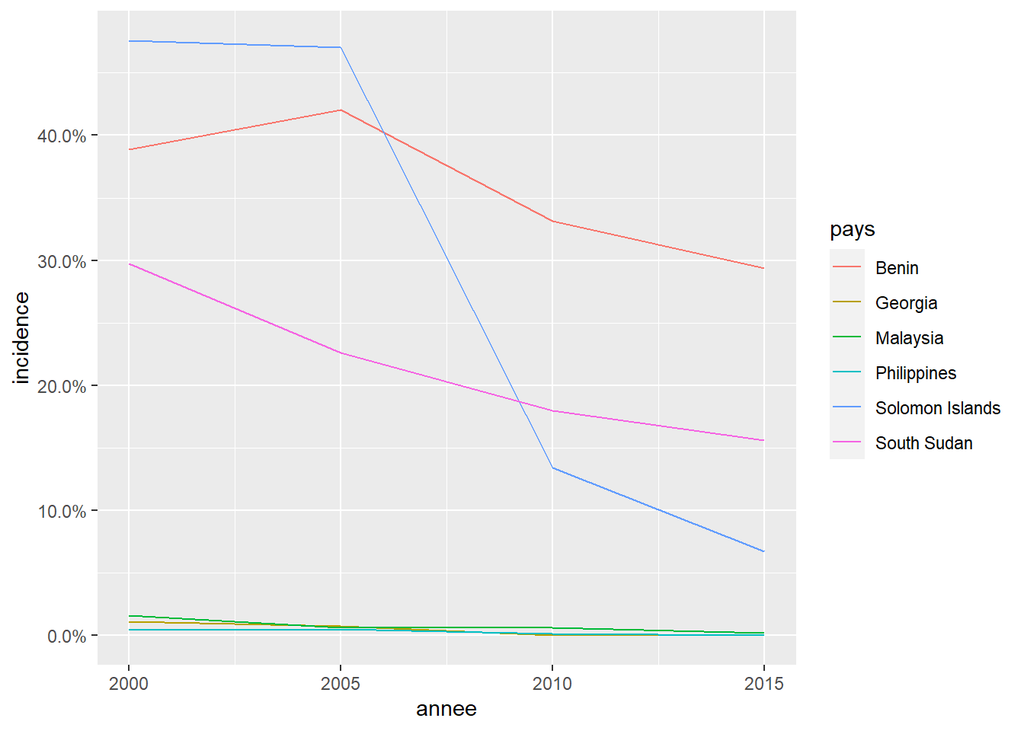

[output not shown]

```r
malaria_processus_inc %>%
  filter(pays %in% sample(unique(pays), 6)) %>%
  ggplot(aes(annee, incidence, color = pays)) +
  geom_line()+
  scale_y_continuous(labels = scales::percent_format())
```

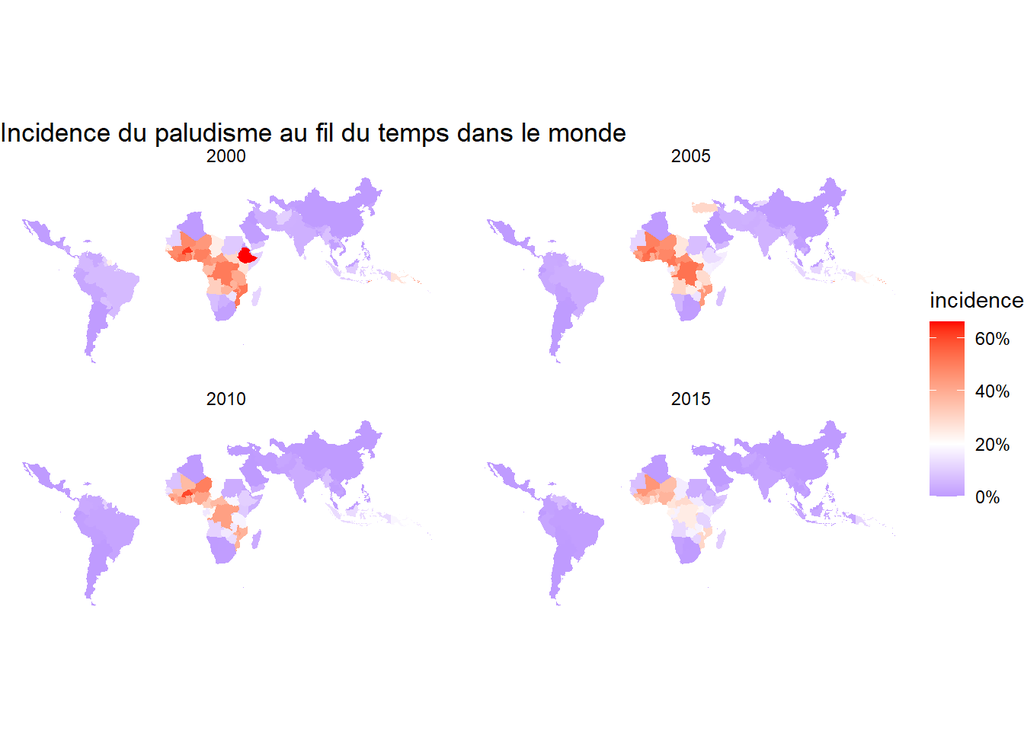

[output not shown]

```r
#comme les région de l'antarctique ne sont pas touché par le paludisme on les enleve par un filtre
world <- map_data("world") %>%
  filter(region != "Antarctica")

malaria_processus_inc %>%
  filter(incidence < 1) %>%
  inner_join(maps::iso3166 %>%
               select(a3, mapname), by = c(code = "a3")) %>%
  inner_join(world, by = c(mapname = "region")) %>%
  ggplot(aes(long, lat, group = group, fill = incidence)) +
  geom_polygon() +
  scale_fill_gradient2(low = "blue", high = "red", midpoint = .20, labels = scales::percent_format()) +
  coord_map() +
  facet_wrap(~ annee) +
  theme_void() +
  labs(title = "Incidence du paludisme au fil du temps dans le monde")
```

```r
malaria_processus_inc %>%
  group_by(pays,annee) %>%
  summarise(incidence = sum(incidence)) %>%
  count(incidence)%>%
  filter(incidence == 0) %>%
  select(pays)
```

```
## # A tibble: 11 x 1
## # Groups:   pays [11]
##    pays
##    <chr>
##  1 Argentina
##  2 Azerbaijan
##  3 Costa Rica
##  4 Georgia
##  5 Iraq
##  6 Kyrgyzstan
##  7 Paraguay
##  8 Sri Lanka
##  9 Tajikistan
## 10 Turkey
## 11 Uzbekistan
```

```
  ##  Questions supplémentaires
```

### 1. nombre de cas

Isolez uniquement les pays qui ont au des cas en 1990 et 2016. Plottez le nombre de cas dans les deux années par tranche d’âge. Choisissez le plot que vous voulez mais le lot doit montrer 1. les classes d’âge avec le plus / moins de cas; 2. l’évolution entre 1990 et 2016. Essayez de ne pas faire un spaghetti-plot, il faut qu’on comprenne les tendances générales.

#POUR 1990

```r
data %>%
  filter(annee %in% c(1990) & nbr.deces > 1 )  -> data2# ON filtre la base en 1990 et les #pays qui ont enrigistrer au moin un cas en 1990 et  on fait la meme chose en 2016.

data2 %>%
  group_by(pays)%>%
  count(nbr.deces)%>%
  filter(nbr.deces!=0)
```

```
## # A tibble: 505 x 3
## # Groups:   pays [114]
##    pays                 nbr.deces     n
##    <chr>                    <dbl> <int>
##  1 Afghanistan              10.7      1
##  2 Afghanistan              53.4      1
##  3 Afghanistan              60.5      1
##  4 Afghanistan             185.       1
##  5 Afghanistan             415.       1
##  6 Algeria                   3.50     1
##  7 Andean Latin America      8.51     1
##  8 Andean Latin America     13.5      1
##  9 Andean Latin America     26.4      1
## 10 Andean Latin America     40.9      1
## # ... with 495 more rows
```

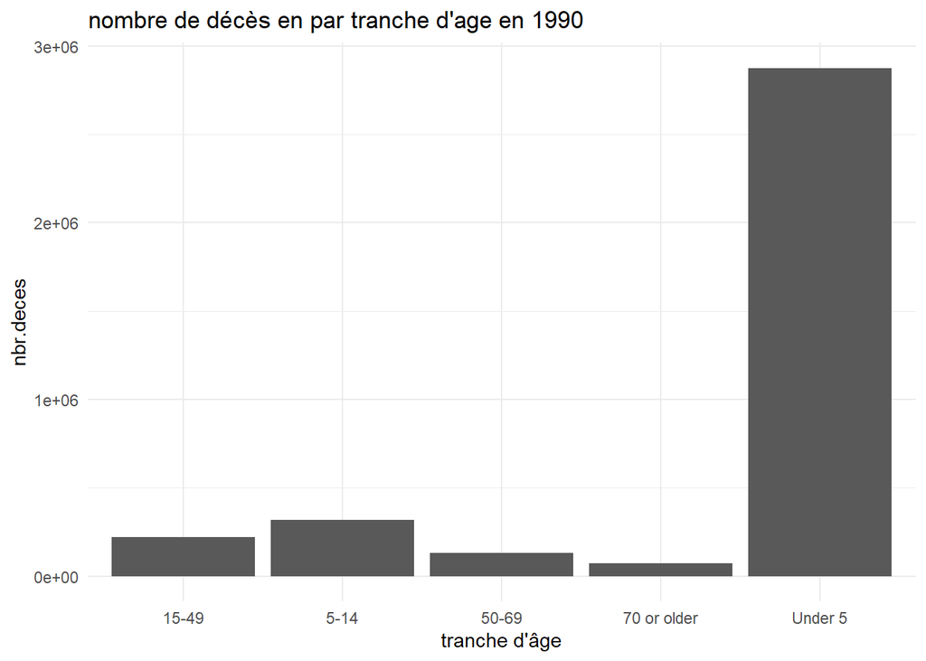

[output not shown]

```r
  ggplot(data2,aes(x=tranche_age, y = nbr.deces), fill)+
  geom_col()+
  labs(title = "nombre de décès en par tranche d'age en 1990")+
  xlab("tranche d'âge")+
  theme_minimal()
```

```r
data %>%
  filter(annee %in% c(2016) & nbr.deces > 1) -> data3
data3 %>%
  group_by(pays)%>%
  count(nbr.deces)%>%
  filter(nbr.deces!=0)
```

```
## # A tibble: 448 x 3
## # Groups:   pays [101]
##    pays                 nbr.deces     n
##    <chr>                    <dbl> <int>
##  1 Afghanistan              35.4      1
##  2 Afghanistan             186.       1
##  3 Afghanistan             189.       1
##  4 Afghanistan             410.       1
##  5 Afghanistan            1326.       1
##  6 Algeria                   1.73     1
##  7 Algeria                   5.12     1
##  8 Andean Latin America      1.89     1
##  9 Andean Latin America      3.68     1
## 10 Andean Latin America      4.17     1
## # ... with 438 more rows
```

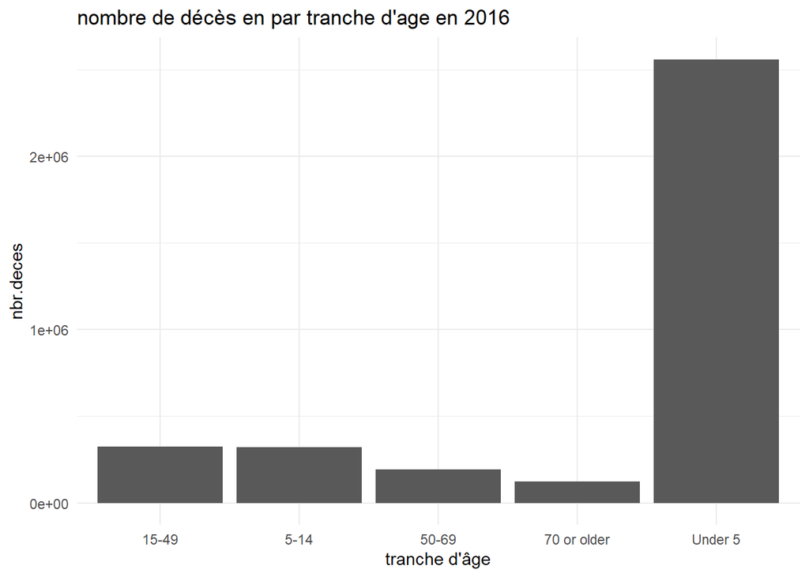

```r
  ggplot(data3,aes(x=tranche_age, y = nbr.deces), fill)+
  geom_col()+
  labs(title = "nombre de décès en par tranche d'age en 2016")+
  xlab("tranche d'âge")+
  theme_minimal()
```

On voit que les jeunes anfants sont principalement victimes du paludisme.C’est le cas en et en 2016.

### 2. Evolution des cas

Isolez uniquement les pays qui ont au des cas en 1990 et 2016. Plottez le nombre de cas totaux pour chacun de ce pays dans un facet différent, avec des points et un smooth. Cela fait beaucoup de facets, mais donne une idée générale de la décroissance des cas.

[figure not shown]

```r
#J'
data %>%
  group_by(pays,annee)%>%
  #summarise(nbr.deces = sum(nbr.deces))%>%
  ggplot(aes(data,x=annee,y=nbr.deces,group=pays))+
  geom_line()+
  geom_smooth()+
  facet_wrap(~pays)
```

```r
  #facet_wrap_paginate(~pays, nrow= 1,ncol = 6,page = 1) #pour afficher le graphe par #page
  #facet_wrap_paginate(~pays, nrow = 1,ncol = 3,page = 2)
  #facet_wrap_paginate(~pays, nrow = 1,ncol = 3,page = 3)
```

### 3. Est-ce que le nombre de cas a diminué dans tous les pays?

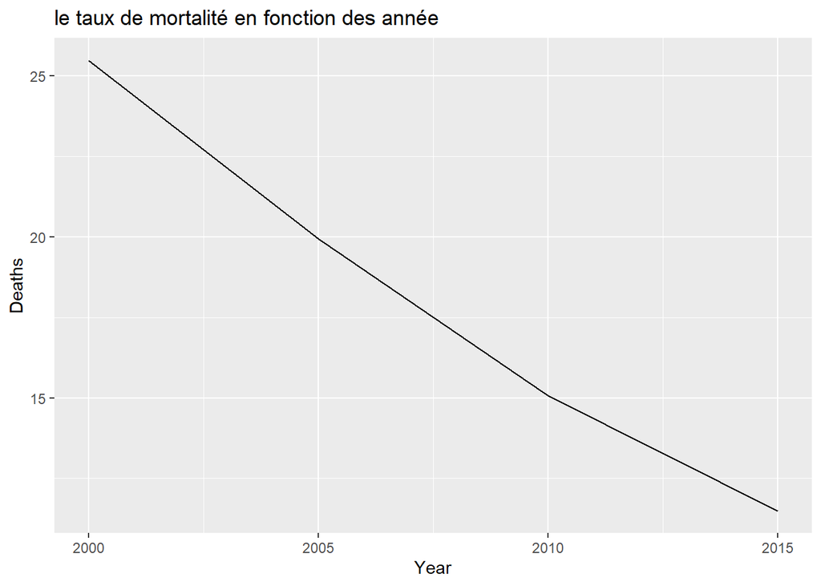

```r
malaria_processus_inc %>%
  group_by(annee) %>%
  summarise(incidence= sum(incidence)) %>%
  ggplot (aes(x = annee, y = incidence)) +
  geom_line() +

  scale_x_continuous(breaks = seq(2000,2015, by = 5)) +
  labs(title = "le taux de mortalité en fonction des année ",
       y = "Deaths",
       x = "Year")
```

```r
#les 5 pays qui enrigistrer plus de deces entre 2000 et 2015

malaria_deaths_filtered_year <- malaria_processus_inc %>%
  filter(annee==2000 ||annee==2015)
worst_countries <- malaria_deaths_filtered_year %>%
  group_by(pays) %>%
  summarise(incidence = sum(incidence)) %>%
  arrange(desc(incidence))%>%
  head(5)
worst_countries
```

```
## # A tibble: 5 x 2
##   pays          incidence
##   <chr>             <dbl>
## 1 Burkina Faso       2.16
## 2 Turkey             2.04
## 3 Cote d'Ivoire      1.85
## 4 Togo               1.82
## 5 Mali               1.79
```

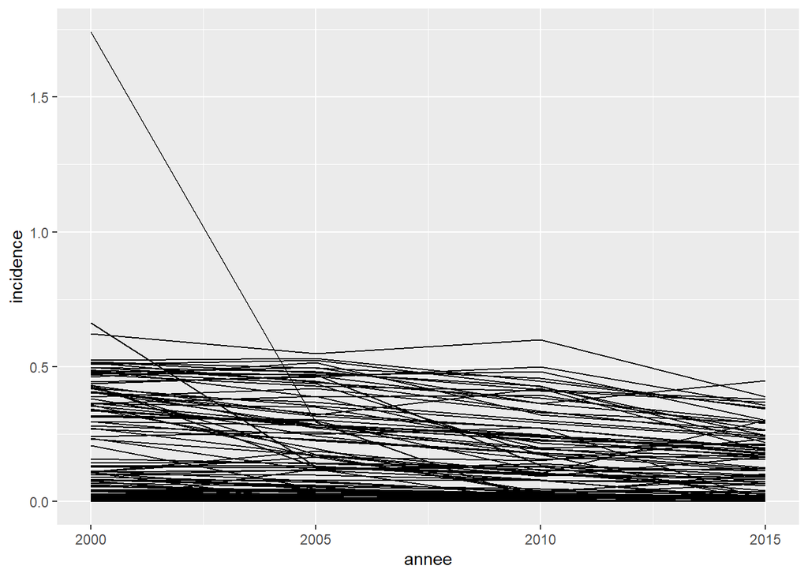

```r
ggplot(malaria_processus_inc,aes(x=annee,y=incidence,,couleur = pays))+geom_line()
```